# R Notebook

```r
library(GGally)
```

### Question 1

- You might like to think about removing some or all of `date`, `id`, `sqft_living15`, `sqft_lot15` and `zipcode` (`lat` and `long` provide a better measure of location in any event).
- Have a think about how to treat `waterfront`. Should we convert its type?
- We converted `yr_renovated` into a `renovated` logical variable, indicating whether the property had ever been renovated. You may wish to do the same.
- Have a think about how to treat `view`, `condition` and `grade`. Are they interval or categorical ordinal data types?

```r
kc_house_trim <- kc_house %>%
  select(-c(id, date, zipcode, sqft_living15, sqft_lot15)) %>%
  rename(renovated = yr_renovated) %>%
  mutate(waterfront = if_else(waterfront == 1, TRUE, FALSE),
         renovated = if_else(renovated != 0, TRUE, FALSE),
         view = case_when(view == 0 ~ "NONE",
                          view == 1 ~ "POOR",
                          view == 2 ~ "AVERAGE",
                          view == 3 ~ "GOOD",
                          view == 4 ~ "VERY GOOD"),
         condition = case_when(condition == 1 ~ "VERY POOR",
                               condition == 2 ~ "POOR",
                               condition == 3 ~ "AVERAGE",
                               condition == 4 ~ "GOOD",
                               condition == 5 ~ "VERY GOOD"),
         grade = case_when(grade >= 11 ~ "VERY HIGH",
                           grade >= 9 ~ "HIGH",
                           grade >= 6 ~ "AVERAGE",
                           grade >= 4 ~ "POOR",
                           TRUE ~ "VERY POOR")
         )

kc_house_trim
```

| price | bedrooms | bathrooms | sqft_living | sqft_lot | floors | waterfront | view | condition | grade | sqft_above | sqft_basement | yr_built | renovated | lat | long |
| --- | --- | --- | --- | --- | --- | --- | --- | --- | --- | --- | --- | --- | --- | --- | --- |
| 221900 | 3 | 1.00 | 1180 | 5650 | 1.0 | FALSE | NONE | AVERAGE | AVERAGE | 1180 | 0 | 1955 | FALSE | 47.5112 | -122.257 |
| 538000 | 3 | 2.25 | 2570 | 7242 | 2.0 | FALSE | NONE | AVERAGE | AVERAGE | 2170 | 400 | 1951 | TRUE | 47.7210 | -122.319 |
| 180000 | 2 | 1.00 | 770 | 10000 | 1.0 | FALSE | NONE | AVERAGE | AVERAGE | 770 | 0 | 1933 | FALSE | 47.7379 | -122.233 |
| 604000 | 4 | 3.00 | 1960 | 5000 | 1.0 | FALSE | NONE | VERY GOOD | AVERAGE | 1050 | 910 | 1965 | FALSE | 47.5208 | -122.393 |
| 510000 | 3 | 2.00 | 1680 | 8080 | 1.0 | FALSE | NONE | AVERAGE | AVERAGE | 1680 | 0 | 1987 | FALSE | 47.6168 | -122.045 |
| 1225000 | 4 | 4.50 | 5420 | 101930 | 1.0 | FALSE | NONE | AVERAGE | VERY HIGH | 3890 | 1530 | 2001 | FALSE | 47.6561 | -122.005 |
| 257500 | 3 | 2.25 | 1715 | 6819 | 2.0 | FALSE | NONE | AVERAGE | AVERAGE | 1715 | 0 | 1995 | FALSE | 47.3097 | -122.327 |
| 291850 | 3 | 1.50 | 1060 | 9711 | 1.0 | FALSE | NONE | AVERAGE | AVERAGE | 1060 | 0 | 1963 | FALSE | 47.4095 | -122.315 |
| 229500 | 3 | 1.00 | 1780 | 7470 | 1.0 | FALSE | NONE | AVERAGE | AVERAGE | 1050 | 730 | 1960 | FALSE | 47.5123 | -122.337 |
| 323000 | 3 | 2.50 | 1890 | 6560 | 2.0 | FALSE | NONE | AVERAGE | AVERAGE | 1890 | 0 | 2003 | FALSE | 47.3684 | -122.031 |

[output cut: 990 more lines]

Unsure whether to use the dummy_cols() function to treat the categorical ordinal data types (view, condition, grade).

### Question 2

- Check for aliased variables using the alias() function (this takes in a formula object and a data set).  
  [Hint - formula price ~ . says ‘price varying with all predictors’, this is a suitable input to alias()].
- Remove variables that lead to an alias. Check the ‘Elements of multiple regression’ lesson for a dropdown containing further information on finding aliased variables in a dataset.

```r
alias(lm(price ~ ., data = kc_house_trim))
```

```
Model :
price ~ bedrooms + bathrooms + sqft_living + sqft_lot + floors +
    waterfront + view + condition + grade + sqft_above + sqft_basement +
    yr_built + renovated + lat + long

Complete :
              (Intercept) bedrooms bathrooms sqft_living sqft_lot floors waterfrontTRUE viewGOOD viewNONE
sqft_basement  0           0        0         1           0        0      0              0        0
              viewPOOR viewVERY GOOD conditionGOOD conditionPOOR conditionVERY GOOD conditionVERY POOR gradeHIGH
sqft_basement  0        0             0             0             0                  0                  0
              gradePOOR gradeVERY HIGH gradeVERY POOR sqft_above yr_built renovatedTRUE lat long
sqft_basement  0         0              0             -1          0        0             0   0
```

The sqft_basement can be deduced by calculating sqft_living - sqft_above, therefore it can be dropped.

```r
kc_house_trim <- kc_house_trim %>%
  select(-sqft_basement)

kc_house_trim
```

| price | bedrooms | bathrooms | sqft_living | sqft_lot | floors | waterfront | view | condition | grade | sqft_above | yr_built | renovated | lat | long |
| --- | --- | --- | --- | --- | --- | --- | --- | --- | --- | --- | --- | --- | --- | --- |
| 221900 | 3 | 1.00 | 1180 | 5650 | 1.0 | FALSE | NONE | AVERAGE | AVERAGE | 1180 | 1955 | FALSE | 47.5112 | -122.257 |
| 538000 | 3 | 2.25 | 2570 | 7242 | 2.0 | FALSE | NONE | AVERAGE | AVERAGE | 2170 | 1951 | TRUE | 47.7210 | -122.319 |
| 180000 | 2 | 1.00 | 770 | 10000 | 1.0 | FALSE | NONE | AVERAGE | AVERAGE | 770 | 1933 | FALSE | 47.7379 | -122.233 |
| 604000 | 4 | 3.00 | 1960 | 5000 | 1.0 | FALSE | NONE | VERY GOOD | AVERAGE | 1050 | 1965 | FALSE | 47.5208 | -122.393 |
| 510000 | 3 | 2.00 | 1680 | 8080 | 1.0 | FALSE | NONE | AVERAGE | AVERAGE | 1680 | 1987 | FALSE | 47.6168 | -122.045 |
| 1225000 | 4 | 4.50 | 5420 | 101930 | 1.0 | FALSE | NONE | AVERAGE | VERY HIGH | 3890 | 2001 | FALSE | 47.6561 | -122.005 |
| 257500 | 3 | 2.25 | 1715 | 6819 | 2.0 | FALSE | NONE | AVERAGE | AVERAGE | 1715 | 1995 | FALSE | 47.3097 | -122.327 |
| 291850 | 3 | 1.50 | 1060 | 9711 | 1.0 | FALSE | NONE | AVERAGE | AVERAGE | 1060 | 1963 | FALSE | 47.4095 | -122.315 |
| 229500 | 3 | 1.00 | 1780 | 7470 | 1.0 | FALSE | NONE | AVERAGE | AVERAGE | 1050 | 1960 | FALSE | 47.5123 | -122.337 |
| 323000 | 3 | 2.50 | 1890 | 6560 | 2.0 | FALSE | NONE | AVERAGE | AVERAGE | 1890 | 2003 | FALSE | 47.3684 | -122.031 |

[output cut: 990 more lines]

### Question 3

Systematically build a regression model containing up to four main effects (remember, a main effect is just a single predictor with coefficient), testing the regression diagnostics as you go and the same in subsequent rounds of predictor selection with the resid column.  
[Hint - Splitting datasets into numeric and non-numeric columns might help ggpairs() run in manageable time, although you will need to add either a price or resid column to the non-numeric dataframe in order to see its correlations with the non-numeric predictors].

Remember, if you are not sure whether including a categorical predictor is statistically justified, run an anova() test passing in the models with- and without the categorical predictor and check the p-value of the test.

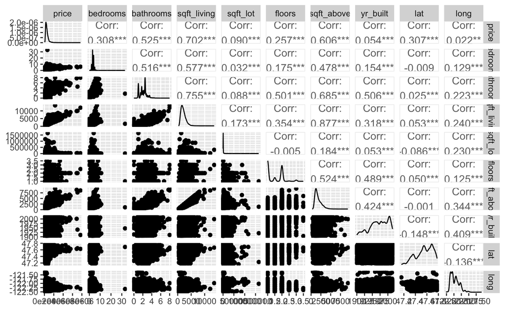

```r
houses_tidy_numeric <- kc_house_trim %>%
  select_if(is.numeric)

houses_tidy_nonnumeric <- kc_house_trim %>%
  select_if(function(x) !is.numeric(x))

houses_tidy_nonnumeric$price <- kc_house_trim$price

ggpairs(houses_tidy_numeric)
```

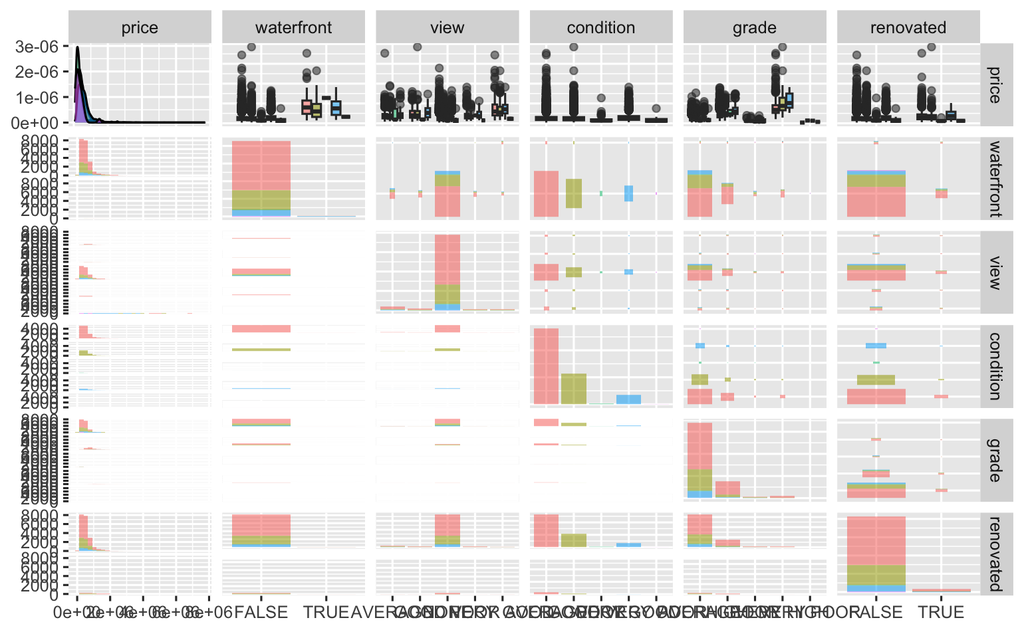

```r
houses_tidy_nonnumeric %>%
  select(price, everything()) %>%
  ggpairs(aes(colour = condition, alpha = 0.5))
```

*Non numeric*